# Distribusi Diskrit I

## 7.2 Binomial

- **Output**

```r
library(diskrit1)
data_binomial <- c(5, 3, 4, 2, 3, 4, 5, 5, 3, 2,
                   4, 4, 5, 3, 2, 5, 4, 4, 3, 5)
size <- 5
# Estimasi probabilitas keberhasilan per soal
estimasi_p_binomial(data_binomial, size = 5)
```

```
## Estimasi p (p̂) Binomial: 0.75
```

```
## [1] 0.75
```

> **Nomor 1**

> Didapatkan hasil p̂ = 0.75 maka rata-rata mahasiswa bisa menjawab 75% soal kuis dengan benar.

```
## Jumlah Observasi: 20
## Percobaan per Observasi: 5
## Estimasi Probabilitas Sukses p̂: 0.75
```

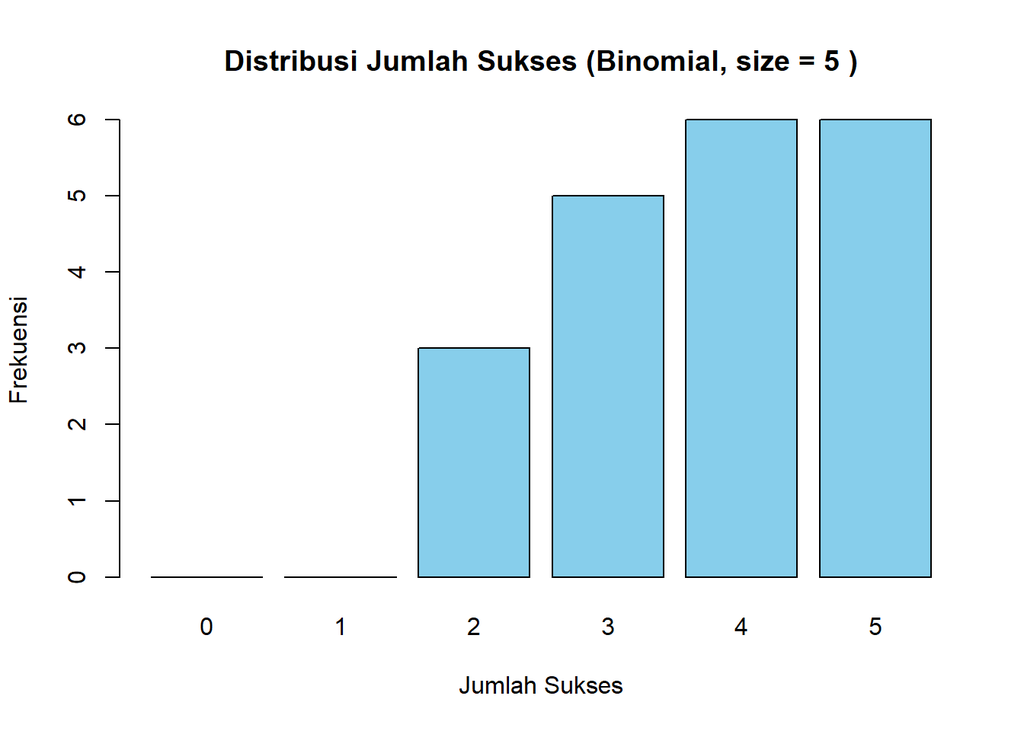

```r
# Visualisasi jumlah sukses
plot_binomial(data_binomial, size = 5)
```

> **Nomor 2**

> Barplot menunjukkan dominasi pada skor 4 dan 5.

> **Nomor 3**

> Dapat disimpulkan apabila sebagian besar mahasiswa memahami materi kuis, walaupun terdapat minoritas yang menjawab hanya 2 soal benar.

```r
# PMF: Peluang tepat 3 benar
pmf_binomial(x = 3, size = 5, p = 0.75)
```

```
## [1] 0.2636719
```

> **Nomor 4**

> Berdasarkan model distribusi binomial dengan peluang keberhasilan 75%, maka peluang bahwa seorang mahasiswa menjawab tepat 3 soal benar dari total 5 soal adalah sekitar 26.37%. Ini berarti bahwa dalam populasi mahasiswa, sekitar 1 dari 4 kemungkinan akan menjawab tepat 3 soal benar saat  
> peluang menjawab benar untuk tiap soal adalah 75%..

```r
# CDF: Peluang ≤ 2 benar (P(X ≤ 2))
cdf_binomial(x = 2, size = 5, p = 0.75)
```

```
## [1] 0.1035156
```

> **Nomor 5**

> Berdasarkan distribusi binomial dengan probabilitas mahasiswa yang menjawab soal dengan benar sebesar 75%, sedangkan peluang bahwa seorang mahasiswa hanya dapat menjawab paling banyak 2 dari 5 soal dengan benar adalah sekitar 10.35%. Karena itu dapat diartikan kemungkinan mahasiswa dengan pemahaman cukup baik hanya menjawab dua > soal atau kurang benar sangat kecil. Hal ini menunjukkan bahwa sebagian besar mahasiswa cenderung mampu menjawab lebih dari 2 soal dengan benar dalam kondisi tersebut.

> Sekian yang dapat kami paparkan dalam Rmarkdown ini mohon maaf apabila masih terdapat banyak kesalahan, kami ucapkan terimakasih🌹

> Packages `diskrit1` ini dapat digunakan dengan menjalankan *syntax* berikut :

> ```r
> devtools::install_github("adibmh/diskrit1")
> library(diskrit1)
> ```